# E19346_EM_317_Assignment_05

### **EM 317 COMPUTATIONAL METHODS**

### **Assignment 05**

#### **SAMARATHUNGE S.M.T.N. (E/19/346)**

### **Question 01**

Given the Function,

$$ f(x) = \begin{cases} x + \pi & \text{if } -\pi \leq x \leq 0 \\ \pi & \text{if } 0 < x < \pi \end{cases} $$

Fourier Series Formula,

$$ f(x) \sim \frac{a_0}{2} + \sum_{n=1}^{\infty} \left( a_n \cos(nx) + b_n \sin(nx) \right) $$

Coefficients Formulas,

$$ a_0 = \frac{1}{\pi} \int_{-\pi}^{\pi} f(x) \, dx $$

$$ a_n = \frac{1}{\pi} \int_{-\pi}^{\pi} f(x) \cos(nx) \, dx $$

$$ b_n = \frac{1}{\pi} \int_{-\pi}^{\pi} f(x) \sin(nx) \, dx $$

```python
from sympy import symbols, pi, integrate, cos, sin, Piecewise

# Define the variable and function
x, n = symbols('x n')
f = Piecewise((x + pi, (x >= -pi) & (x <= 0)), (pi, (x > 0) & (x < pi)))

# Calculate a0, an, bn
a0 = (1/pi) * integrate(f, (x, -pi, pi))
an = (1/pi) * integrate(f * cos(n*x), (x, -pi, pi))
bn = (1/pi) * integrate(f * sin(n*x), (x, -pi, pi))

a0, an, bn
```

```
(3*pi/2,
 Piecewise((pi*sin(pi*n)/n - cos(pi*n)/n**2 + n**(-2), (n > -oo) & (n < oo) & Ne(n, 0)), (3*pi**2/2, True))/pi,
 Piecewise((-pi*cos(pi*n)/n + sin(pi*n)/n**2, (n > -oo) & (n < oo) & Ne(n, 0)), (0, True))/pi)
```

Calculated Coefficients,

$$ a_0 = \frac{3\pi}{2} $$

$$ a_n = \frac{1}{\pi} \left( \frac{\pi \sin(\pi n)}{n} - \frac{\cos(\pi n)}{n^2} + \frac{1}{n^2} \right) $$

$$ b_n = \frac{1}{\pi} \left( -\frac{\pi \cos(\pi n)}{n} + \frac{\sin(\pi n)}{n^2} \right) $$

```python
from sympy import sin, cos, simplify

# Simplify an and bn for n even and odd
an_even = simplify(an.subs(n, 2*n))
an_odd = simplify(an.subs(n, 2*n + 1))
bn_even = simplify(bn.subs(n, 2*n))
bn_odd = simplify(bn.subs(n, 2*n + 1))

an_even, an_odd, bn_even, bn_odd
```

```
(Piecewise(((2*pi*n*sin(2*pi*n) - cos(2*pi*n) + 1)/(4*pi*n**2), ((n > -oo) | (n > 0)) & ((n > -oo) | (n < oo)) & ((n > 0) | (n < 0)) & ((n < 0) | (n < oo))), (3*pi/2, True)),
 Piecewise(((-pi*(2*n + 1)*sin(2*pi*n) + cos(2*pi*n) + 1)/(pi*(2*n + 1)**2), ((n > -oo) | (n > -1/2)) & ((n > -oo) | (n < oo)) & ((n > -1/2) | (n < -1/2)) & ((n < -1/2) | (n < oo))), (3*pi/2, True)),
 Piecewise(((-2*cos(2*pi*n) + sin(2*pi*n)/(pi*n))/(4*n), ((n > -oo) | (n > 0)) & ((n > -oo) | (n < oo)) & ((n > 0) | (n < 0)) & ((n < 0) | (n < oo))), (0, True)),
 Piecewise(((pi*(2*n + 1)*cos(2*pi*n) - sin(2*pi*n))/(pi*(2*n + 1)**2), ((n > -oo) | (n > -1/2)) & ((n > -oo) | (n < oo)) & ((n > -1/2) | (n < -1/2)) & ((n < -1/2) | (n < oo))), (0, True)))
```

Simplified Coefficients for Even and Odd $n$,

For even $n$,

$$ a_n = \frac{2\pi n \sin(2\pi n) - \cos(2\pi n) + 1}{4\pi n^2} $$

$$ b_n = \frac{-2\cos(2\pi n) + \frac{\sin(2\pi n)}{\pi n}}{4n} $$

For odd $n$,

$$ a_n = \frac{-\pi(2n + 1)\sin(2\pi n) + \cos(2\pi n) + 1}{\pi(2n + 1)^2} $$

$$ b_n = \frac{\pi(2n + 1)\cos(2\pi n) - \sin(2\pi n)}{\pi(2n + 1)^2} $$

Where, $$ f(x) \sim \frac{3\pi}{4} + \sum_{n=1}^{\infty} \left( a_n \cos(nx) + b_n \sin(nx) \right) $$

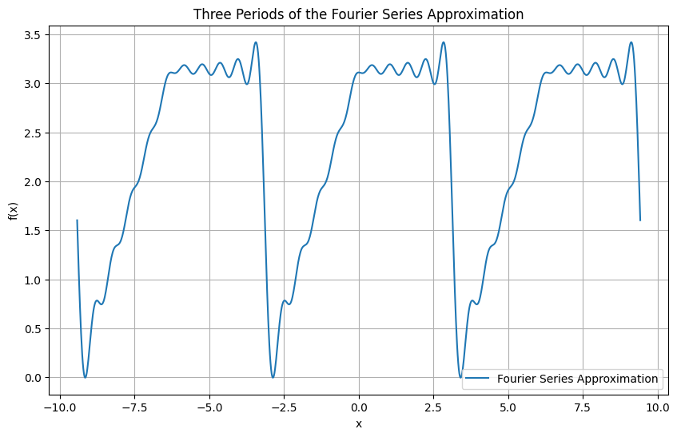

```python
import numpy as np
import matplotlib.pyplot as plt

# Define the Fourier series function
def fourier_series(x, N):
    a0 = 3 * np.pi / 2
    series = a0 / 2
    for n in range(1, N + 1):
        an = (np.pi * np.sin(np.pi * n) / n - np.cos(np.pi * n) / n**2 + 1 / n**2) / np.pi
        bn = (-np.pi * np.cos(np.pi * n) / n + np.sin(np.pi * n) / n**2) / np.pi
        series += an * np.cos(n * x) + bn * np.sin(n * x)
    return series

# Plotting
x = np.linspace(-3 * np.pi, 3 * np.pi, 1000)
N = 10  # Number of terms in the Fourier series

plt.figure(figsize=(10, 6))
plt.plot(x, fourier_series(x, N), label="Fourier Series Approximation")
plt.xlabel('x')
plt.ylabel('f(x)')
plt.title('Three Periods of the Fourier Series Approximation')
plt.grid(True)
plt.legend()
plt.show()
```

### **Question 02**

(a) Given the function:

$$ f(x) = \begin{cases} x & \text{if } 0 \leq x < 1 \\ 1 & \text{if } 1 \leq x < 2 \end{cases} $$

Since $f$ is odd, \ $$a_0 = 0\ and\ a_n = 0$$

Therefore, for an odd periodic function with period $ P $, the Fourier sine series is given by:

$$ f(x) \sim \sum_{n=1}^{\infty} b_n \sin\left(\frac{n\pi x}{L}\right) $$

where $ L = P/2 $ and

$$ b_n = \frac{2}{L} \int_{0}^{L} f(x) \sin\left(\frac{n\pi x}{L}\right) dx $$

Here, $ L = 4/2 = 2 $.

$$ b_n = \frac{2}{2} \int_{0}^{2} f(x) \sin\left(\frac{n\pi x}{2}\right) dx $$

Since $ f(x) $ is piecewise defined, the integral will be split into two parts:

$$ b_n = \int_{0}^{1} x \sin\left(\frac{n\pi x}{2}\right) dx + \int_{1}^{2} 1 \cdot \sin\left(\frac{n\pi x}{2}\right) dx $$

Calculating $ b_n $:

```python
from sympy import symbols, pi, integrate, sin

# Defining the symbols
x, n = symbols('x n')

# Defining the function for the two intervals
f1 = x * sin(n*pi*x/2)
f2 = sin(n*pi*x/2)

# Calculate bn for each n
bn = integrate(f1, (x, 0, 1)) + integrate(f2, (x, 1, 2))

bn.simplify()
```

$\displaystyle \begin{cases} \frac{2 \left(- \pi n \cos{\left(\pi n \right)} + 2 \sin{\left(\frac{\pi n}{2} \right)}\right)}{\pi^{2} n^{2}} & \text{for}\: \left(n > -\infty \vee n > 0\right) \wedge \left(n > -\infty \vee n < \infty\right) \wedge \left(n > 0 \vee n < 0\right) \wedge \left(n < 0 \vee n < \infty\right) \\0 & \text{otherwise} \end{cases}$

Simplified Coefficients,

$$ b_n = \frac{2\left(-\pi n \cos(\pi n) + 2 \sin\left(\frac{\pi n}{2}\right)\right)}{\pi^2 n^2} $$

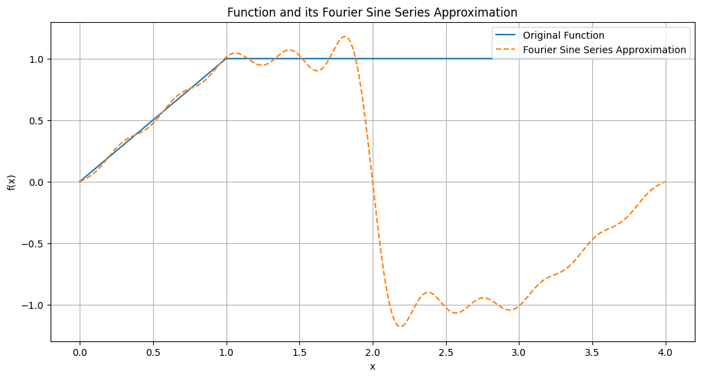

```python
import numpy as np
import matplotlib.pyplot as plt

# Defining the original function
def original_function(x):
    return np.where(x < 1, x, 1)

# Defining the Fourier sine series function
def fourier_sine_series(x, N):
    L = 2
    series = 0
    for n in range(1, N + 1):
        bn = 2 * (-np.pi * n * np.cos(np.pi * n) + 2 * np.sin(np.pi * n / 2)) / (np.pi**2 * n**2)
        series += bn * np.sin(n * np.pi * x / L)
    return series

# Plotting
x_values = np.linspace(0, 4, 500)  # One period
N = 10  # Number of terms in the Fourier series

plt.figure(figsize=(12, 6))
plt.plot(x_values, original_function(x_values), label="Original Function")
plt.plot(x_values, fourier_sine_series(x_values, N), label="Fourier Sine Series Approximation", linestyle='--')
plt.xlabel('x')
plt.ylabel('f(x)')
plt.title('Function and its Fourier Sine Series Approximation')
plt.grid(True)
plt.legend()
plt.show()
```

(b) Given the function,

$$ f(x) = L - x, \quad 0 \leq x \leq L $$

Fourier Cosine Series Formula,

$$ f(x) \sim \frac{a_0}{2} + \sum_{n=1}^{\infty} a_n \cos\left(\frac{n\pi x}{L}\right) $$

Coefficient Formulas,

$$ a_0 = \frac{1}{L} \int_{0}^{L} f(x) \, dx $$

$$ a_0 = \frac{1}{L} \int_{0}^{L} (L - x) \, dx $$

$$ a_n = \frac{2}{L} \int_{0}^{L} f(x) \cos\left(\frac{n\pi x}{L}\right) dx $$

$$ a_n = \frac{2}{L} \int_{0}^{L} (L - x) \cos\left(\frac{n\pi x}{L}\right) dx $$

```python
from sympy import symbols, pi, integrate, cos

# Defining the symbols
x, L, n = symbols('x L n')

# Defining the function
f = L - x

# Calculating a0 and an
a0 = (1/L) * integrate(f, (x, 0, L))
an = (2/L) * integrate(f * cos(n*pi*x/L), (x, 0, L))

a0.simplify(), an.simplify()
```

```
(L/2,
 Piecewise((2*L*(1 - cos(pi*n))/(pi**2*n**2), ((n > -oo) | (n > 0)) & ((n > -oo) | (n < oo)) & ((n > 0) | (n < 0)) & ((n < 0) | (n < oo))), (L, True)))
```

Calculated Coefficients,

$$ a_0 = \frac{L}{2} $$

$$ a_n = \frac{2L(1 - \cos(\pi n))}{\pi^2 n^2} $$

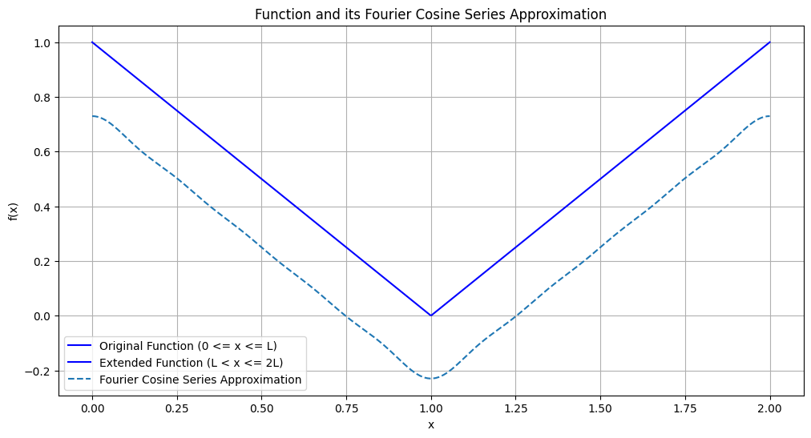

```python
# Define L and the Fourier cosine series function
L_value = 1
def fourier_cosine_series(x, N, L):
    a0 = L / 2
    series = a0 / 2
    for n in range(1, N + 1):
        an = 2 * L * (1 - np.cos(np.pi * n)) / (np.pi**2 * n**2)
        series += an * np.cos(n * np.pi * x / L)
    return series

# Plotting
x_values = np.linspace(0, 2 * L_value, 500)  # One period
N = 10  # Number of terms in the Fourier series

plt.figure(figsize=(12, 6))
plt.plot(x_values[:250], L_value - x_values[:250], label="Original Function (0 <= x <= L)", color='blue')
plt.plot(x_values[250:], x_values[250:] - L_value, label="Extended Function (L < x <= 2L)", color='blue')  # Extended part
plt.plot(x_values, fourier_cosine_series(x_values, N, L_value), label="Fourier Cosine Series Approximation", linestyle='--')
plt.xlabel('x')
plt.ylabel('f(x)')
plt.title('Function and its Fourier Cosine Series Approximation')
plt.grid(True)
plt.legend()
plt.show()
```